# TFM Master Big Data y Data Science, David Perez

## **TFM Master Big Data y Data Science, Universidad Complutense de Madrid.**

## **David Perez Diaz**

*Notas:* *Debido a la configuracion de mi teclado (English Setup) no tengo acceso a la tecla enye, por lo que cada vez que se necesite una enye se vera sustituida por ny.* *Para la consecucion del proyecto utilizamos Google Colab*

Buscamos con este proyecto la obtencion de tres modelos que nos ayuden a construir una aplicacion para que el cliente (un banco en este caso) pueda detectar con mayor facilidad transacciones fraudulentas en su sistema. Nuestro cliente nos ha proveido de una fuente de datos etiquetedas con una serie de caracteristicas de las cuales intentaremos analizar y buscar patrones, con el objetivo de conseguir detectar aquellas transacciones que sean fraudulentas.

1. Objetivo:

Desarrollar una aplicacion con tres modelos de Machine Learning para detectar con mayor precision y flexibilidad las transacciones fraudulentas en el sistema del banco.

2. Metodologia:
- Analisis exhaustivo de datos: Exploracion profunda de la fuente de datos etiquetada proporcionada por el banco, buscando patrones y caracteristicas relevantes para la deteccion de fraude.
- Transformacion de datos: Adecuacion y limpieza de los datos para optimizar el rendimiento de los modelos.
- Desarrollo de tres modelos: Entrenamiento y optimizacion de tres modelos de Machine Learning con distintos niveles de confianza y precision, todos con una precision minima del 90%.
- Implementacion:
  - Paquete de instalacion de Python para facilitar la integracion en el sistema del banco.
  - Pequenya aplicacion con interfaz grafica para la visualizacion y gestion de los modelos.
- Beneficios:
  - Mejora en la deteccion de fraudes: Reduccion significativa de las perdidas por transacciones fraudulentas.
  - Flexibilidad y adaptabilidad: Tres modelos con diferentes niveles de confianza para ajustarse a las necesidades especificas del banco.
  - Precision robusta: Todos los modelos con una precision minima del 90% para garantizar la confiabilidad de las detecciones.
  - Facilidad de uso: Paquete de Python e interfaz grafica intuitiva para una integracion y gestion sencilla.
- Para mas informacion:
  - Repositorio de GitHub: https://github.com/davidpd7/fraud
  - Fuente de los datos: *https://www.kaggle.com/datasets/mlg-ulb/creditcardfraud*

## Indice

1. Importacion de librerias necesarias, datos y interpretacion
2. Exploracion de datos (EDA)
3. Preprocesado
4. Transformacion de variables
5. Modelizacion
6. Tunning parameters
7. Deep Learning
8. Conclusion
9. Anexos

## **1. Importacion de librerias necesarias, datos y interpretacion**

En primer lugar, realizamos la importacion de librerias necesarias para la realizacion del proyecto. El mismo se esta realizando desde la plataforma de Google Colab, por lo que procedemos a la instalacion de librerias no incluidas en el entorno de ejecucion.

> Anexo 1. Codigo importacion de librerias y datos

## **2. Exploracion de datos (EDA)**

> Tabla 1. Informacion del *train dataset*

```python
data_train.info()
```

```
<class 'pandas.core.frame.DataFrame'>
Index: 1296675 entries, 0 to 1296674
Data columns (total 22 columns):
 #   Column                 Non-Null Count    Dtype
---  ------                 --------------    -----
 0   trans_date_trans_time  1296675 non-null  object
 1   cc_num                 1296675 non-null  int64
 2   merchant               1296675 non-null  object
 3   category               1296675 non-null  object
 4   amt                    1296675 non-null  float64
 5   first                  1296675 non-null  object
 6   last                   1296675 non-null  object
 7   gender                 1296675 non-null  object
 8   street                 1296675 non-null  object
 9   city                   1296675 non-null  object
 10  state                  1296675 non-null  object
 11  zip                    1296675 non-null  int64
 12  lat                    1296675 non-null  float64
 13  long                   1296675 non-null  float64
 14  city_pop               1296675 non-null  int64
 15  job                    1296675 non-null  object
 16  dob                    1296675 non-null  object
 17  trans_num              1296675 non-null  object
 18  unix_time              1296675 non-null  int64
 19  merch_lat              1296675 non-null  float64
 20  merch_long             1296675 non-null  float64
 21  is_fraud               1296675 non-null  int64
dtypes: float64(5), int64(5), object(12)
memory usage: 227.5+ MB
```

> Tabla 2. Primeras cinco observacion *train dataset*

```python
data_train.head()
```

|  | trans_date_trans_time | cc_num | merchant | category | amt | first | last | gender | street | city | state | zip | lat | long | city_pop | job | dob | trans_num | unix_time | merch_lat | merch_long | is_fraud |
| --- | --- | --- | --- | --- | --- | --- | --- | --- | --- | --- | --- | --- | --- | --- | --- | --- | --- | --- | --- | --- | --- | --- |
| 0 | 2019-01-01 00:00:18 | 2703186189652095 | fraud_Rippin, Kub and Mann | misc_net | 4.97 | Jennifer | Banks | F | 561 Perry Cove | Moravian Falls | NC | 28654 | 36.0788 | -81.1781 | 3495 | Psychologist, counselling | 1988-03-09 | 0b242abb623afc578575680df30655b9 | 1325376018 | 36.011293 | -82.048315 | 0 |
| 1 | 2019-01-01 00:00:44 | 630423337322 | fraud_Heller, Gutmann and Zieme | grocery_pos | 107.23 | Stephanie | Gill | F | 43039 Riley Greens Suite 393 | Orient | WA | 99160 | 48.8878 | -118.2105 | 149 | Special educational needs teacher | 1978-06-21 | 1f76529f8574734946361c461b024d99 | 1325376044 | 49.159047 | -118.186462 | 0 |
| 2 | 2019-01-01 00:00:51 | 38859492057661 | fraud_Lind-Buckridge | entertainment | 220.11 | Edward | Sanchez | M | 594 White Dale Suite 530 | Malad City | ID | 83252 | 42.1808 | -112.2620 | 4154 | Nature conservation officer | 1962-01-19 | a1a22d70485983eac12b5b88dad1cf95 | 1325376051 | 43.150704 | -112.154481 | 0 |
| 3 | 2019-01-01 00:01:16 | 3534093764340240 | fraud_Kutch, Hermiston and Farrell | gas_transport | 45.00 | Jeremy | White | M | 9443 Cynthia Court Apt. 038 | Boulder | MT | 59632 | 46.2306 | -112.1138 | 1939 | Patent attorney | 1967-01-12 | 6b849c168bdad6f867558c3793159a81 | 1325376076 | 47.034331 | -112.561071 | 0 |
| 4 | 2019-01-01 00:03:06 | 375534208663984 | fraud_Keeling-Crist | misc_pos | 41.96 | Tyler | Garcia | M | 408 Bradley Rest | Doe Hill | VA | 24433 | 38.4207 | -79.4629 | 99 | Dance movement psychotherapist | 1986-03-28 | a41d7549acf90789359a9aa5346dcb46 | 1325376186 | 38.674999 | -78.632459 | 0 |

> Tabla 3. Cardinalidad variables en *train dataset*

```python
data_train.nunique()
```

```
trans_date_trans_time    1274791
cc_num                       983
merchant                     693
category                      14
amt                        52928
first                        352
last                         481
gender                         2
street                       983
city                         894
state                         51
zip                          970
lat                          968
long                         969
city_pop                     879
job                          494
dob                          968
trans_num                1296675
unix_time                1274823
merch_lat                1247805
merch_long               1275745
is_fraud                       2
dtype: int64
```

> Tabla 4. Contabilizacion valores nulos *train* y *test dataset*

```python
print("Missing Values in Train Data:")
print(data_train.isnull().sum())
print("\nMissing Values in Test Data:")
print(data_test.isnull().sum())
```

```
Missing Values in Train Data:
trans_date_trans_time    0
cc_num                   0
merchant                 0
category                 0
amt                      0
first                    0
last                     0
gender                   0
street                   0
city                     0
state                    0
zip                      0
lat                      0
long                     0
city_pop                 0
job                      0
dob                      0
trans_num                0
unix_time                0
merch_lat                0
merch_long               0
is_fraud                 0
dtype: int64

Missing Values in Test Data:
trans_date_trans_time    0
cc_num                   0
merchant                 0
category                 0
amt                      0
first                    0
last                     0
gender                   0
street                   0
city                     0
state                    0
zip                      0
lat                      0
long                     0
city_pop                 0
job                      0
dob                      0
trans_num                0
unix_time                0
merch_lat                0
merch_long               0
is_fraud                 0
dtype: int64
```

> Anexo 2. Categorizacion variables cardinalidad inferior a diez

Nos ayudamos de la reprentacion grafica y descriptiva para obtener mas informacion de los mismos.

> Grafica 1. Histograma variables continuas *train dataset*

```
array([[<Axes: title={'center': 'cc_num'}>,
        <Axes: title={'center': 'amt'}>, <Axes: title={'center': 'zip'}>],
       [<Axes: title={'center': 'lat'}>,
        <Axes: title={'center': 'long'}>,
        <Axes: title={'center': 'city_pop'}>],
       [<Axes: title={'center': 'unix_time'}>,
        <Axes: title={'center': 'merch_lat'}>,
        <Axes: title={'center': 'merch_long'}>]], dtype=object)
```

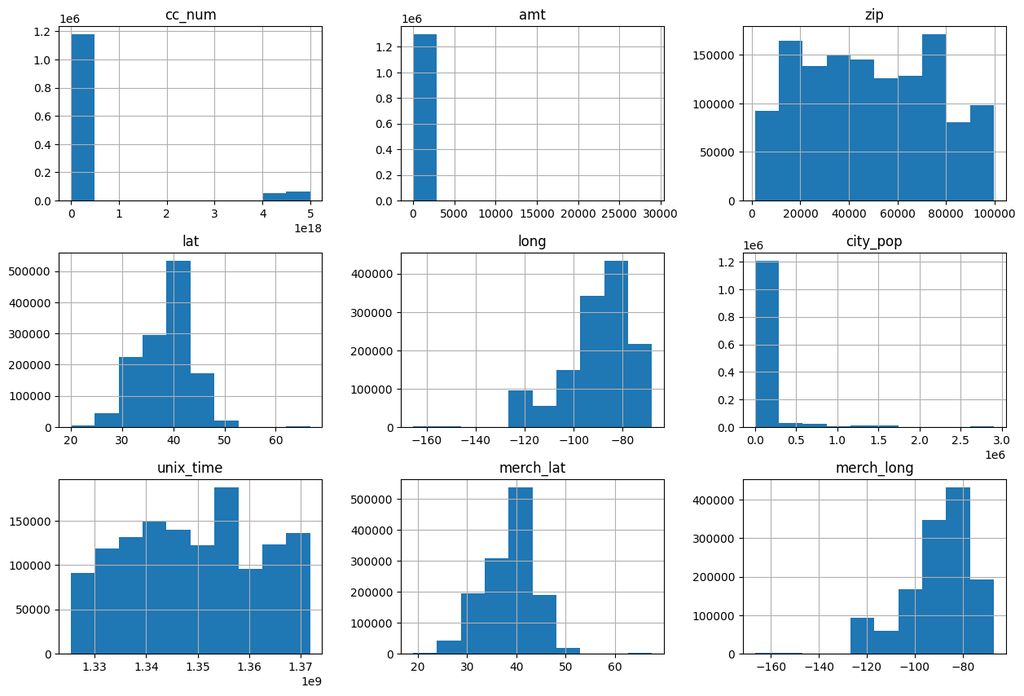

```python
data_train.select_dtypes(include=np.number).hist(figsize=(15,10))
```

> Grafica 2. Histograma distribucion variable objetivo

| is_fraud | Counts | Percentage |
| --- | --- | --- |
| 0 | 553574 | 99.61 |
| 1 | 2145 | 0.39 |

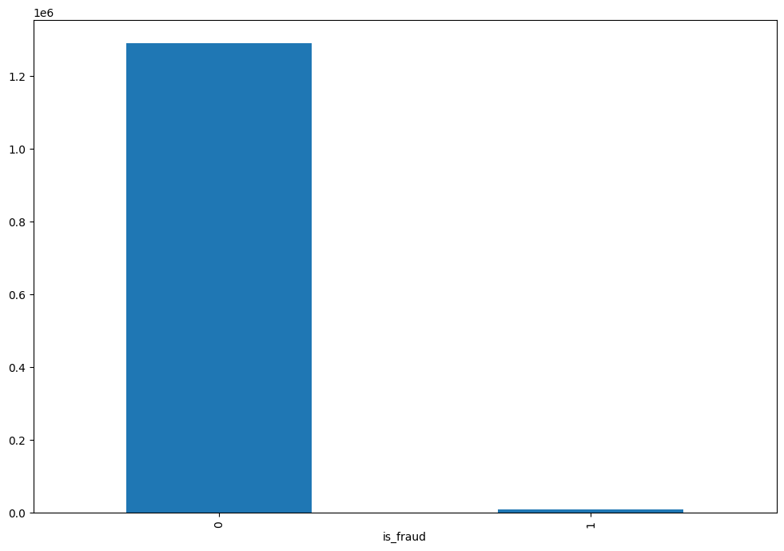

```python
display(pd.DataFrame({"Counts": data_test["is_fraud"].value_counts(),
                    "Percentage": (data_test["is_fraud"].value_counts()/len(data_test)*100).round(2)}))
pd.value_counts(data_train["is_fraud"]).plot.bar()
```

> Tabla 5. Estadistica descriptiva *train dataset* variables continuas

```python
data_train.describe()
```

|  | cc_num | amt | zip | lat | long | city_pop | unix_time | merch_lat | merch_long |
| --- | --- | --- | --- | --- | --- | --- | --- | --- | --- |
| count | 1.296675e+06 | 1.296675e+06 | 1.296675e+06 | 1.296675e+06 | 1.296675e+06 | 1.296675e+06 | 1.296675e+06 | 1.296675e+06 | 1.296675e+06 |
| mean | 4.171920e+17 | 7.035104e+01 | 4.880067e+04 | 3.853762e+01 | -9.022634e+01 | 8.882444e+04 | 1.349244e+09 | 3.853734e+01 | -9.022646e+01 |
| std | 1.308806e+18 | 1.603160e+02 | 2.689322e+04 | 5.075808e+00 | 1.375908e+01 | 3.019564e+05 | 1.284128e+07 | 5.109788e+00 | 1.377109e+01 |
| min | 6.041621e+10 | 1.000000e+00 | 1.257000e+03 | 2.002710e+01 | -1.656723e+02 | 2.300000e+01 | 1.325376e+09 | 1.902779e+01 | -1.666712e+02 |
| 25% | 1.800429e+14 | 9.650000e+00 | 2.623700e+04 | 3.462050e+01 | -9.679800e+01 | 7.430000e+02 | 1.338751e+09 | 3.473357e+01 | -9.689728e+01 |
| 50% | 3.521417e+15 | 4.752000e+01 | 4.817400e+04 | 3.935430e+01 | -8.747690e+01 | 2.456000e+03 | 1.349250e+09 | 3.936568e+01 | -8.743839e+01 |
| 75% | 4.642255e+15 | 8.314000e+01 | 7.204200e+04 | 4.194040e+01 | -8.015800e+01 | 2.032800e+04 | 1.359385e+09 | 4.195716e+01 | -8.023680e+01 |
| max | 4.992346e+18 | 2.894890e+04 | 9.978300e+04 | 6.669330e+01 | -6.795030e+01 | 2.906700e+06 | 1.371817e+09 | 6.751027e+01 | -6.695090e+01 |

> Tabla 6. Estadistica descriptiva *train dataset* variables categoricas

```python
data_train.describe(exclude=np.number)
```

|  | trans_date_trans_time | merchant | category | first | last | gender | street | city | state | job | dob | trans_num | is_fraud |
| --- | --- | --- | --- | --- | --- | --- | --- | --- | --- | --- | --- | --- | --- |
| count | 1296675 | 1296675 | 1296675 | 1296675 | 1296675 | 1296675 | 1296675 | 1296675 | 1296675 | 1296675 | 1296675 | 1296675 | 1296675 |
| unique | 1274791 | 693 | 14 | 352 | 481 | 2 | 983 | 894 | 51 | 494 | 968 | 1296675 | 2 |
| top | 2019-04-22 16:02:01 | fraud_Kilback LLC | gas_transport | Christopher | Smith | F | 0069 Robin Brooks Apt. 695 | Birmingham | TX | Film/video editor | 1977-03-23 | 0b242abb623afc578575680df30655b9 | 0 |
| freq | 4 | 4403 | 131659 | 26669 | 28794 | 709863 | 3123 | 5617 | 94876 | 9779 | 5636 | 1 | 1289169 |

> Grafica 3. Distribucion variables continuas con respecto a la variable objetivo

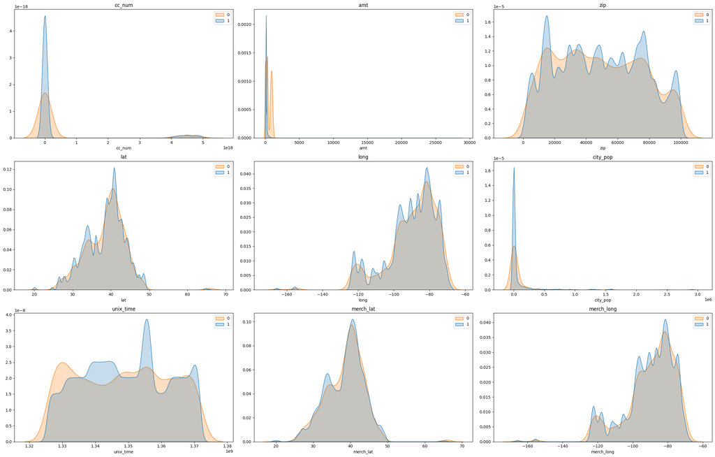

```python
fig, axes = plt.subplots(nrows=3, ncols=3, figsize=(25, 16))
axes = axes.ravel()
numerical_columns = data_train.select_dtypes(include=np.number).columns
for i, column in enumerate(numerical_columns):
    sns.kdeplot(data=data_train, x=column, hue=data_train["is_fraud"], fill=True, common_norm=False, ax=axes[i])
    axes[i].set_title(column)
    axes[i].legend(data_train["is_fraud"].value_counts().index)
    axes[i].set_ylabel("")
plt.tight_layout()
```

> Grafica 4. Diagrama de cajas variable *amt* con respecto a la variable objetivo

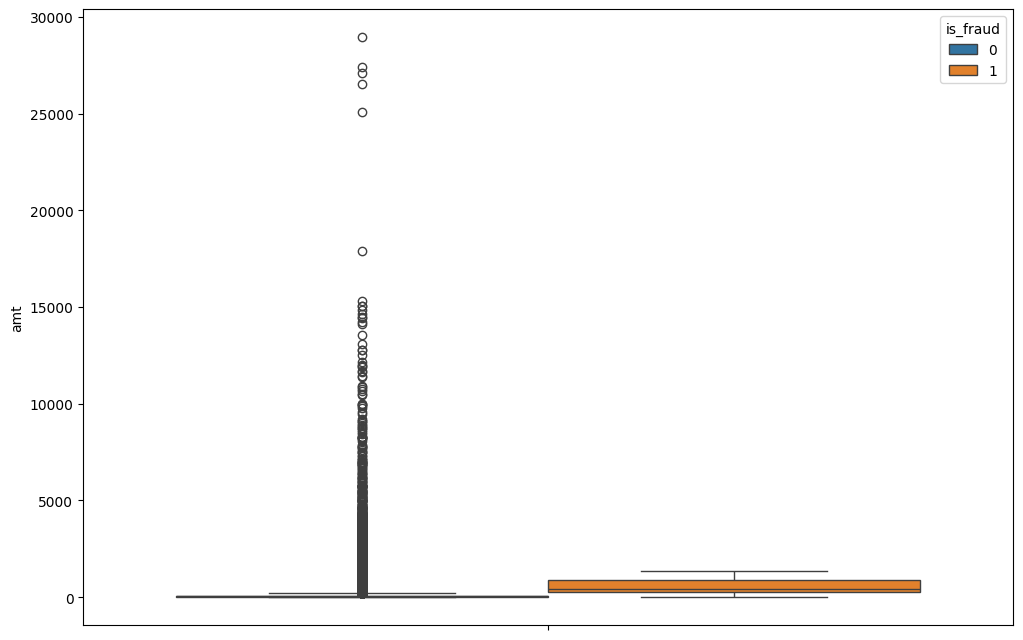

```python
sns.boxplot(y="amt", hue="is_fraud", data=data_train)
```

> Grafica 5. Distribucion variables categoricas con respecto a la variable objetivo. Graficos de las izquierda sin normalizar, graficos de la derecha normalizado

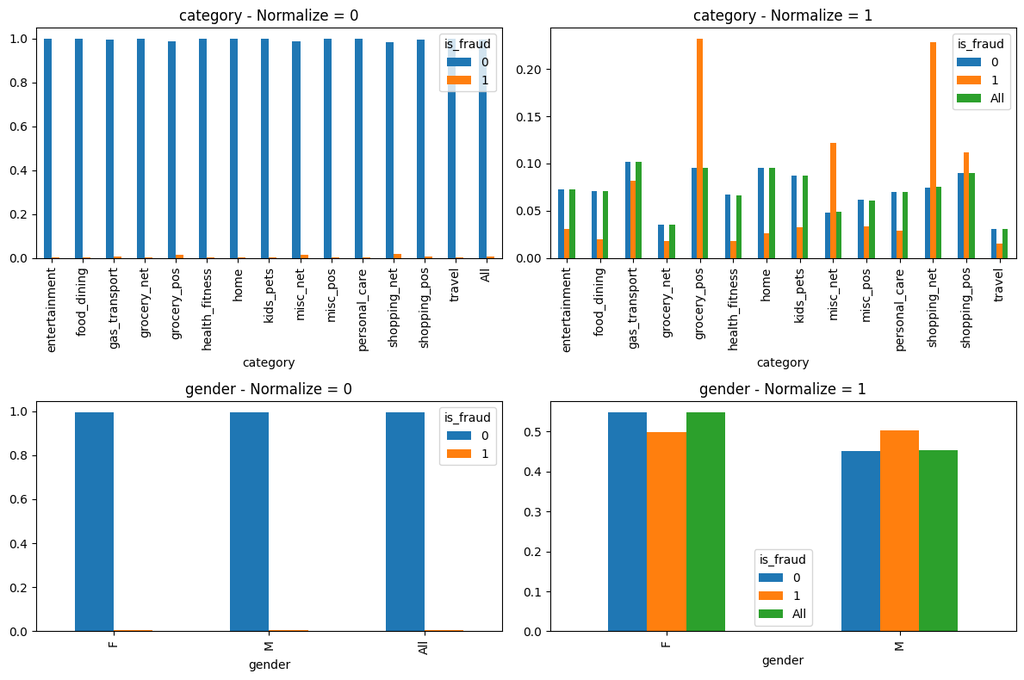

```python
mask = data_train.nunique() < 20
data_cat = data_train.loc[:,mask].drop(columns="is_fraud")
fig, axes = plt.subplots(nrows=len(data_cat.columns), ncols=2)
for index, column in enumerate(data_cat.columns):
    crosstab_n1 = pd.crosstab(data_cat[column], data_train["is_fraud"], margins=True, normalize=1).round(3)
    crosstab_n0 = pd.crosstab(data_cat[column], data_train["is_fraud"], margins=True, normalize=0).round(3)
    crosstab_n0.plot(kind="bar", ax=axes[index, 0])
    axes[index, 0].set_title(f"{column} - Normalize = 0")
    crosstab_n1.plot(kind="bar", ax=axes[index, 1])
    axes[index, 1].set_title(f"{column} - Normalize = 1")
plt.show()
```

## **3. Preprocesado**

Adicionalmente al primer vistazo del *dataset*, observamos una alta descompensacion en la variable objetivo, estando la categoria que buscamos detectar (1 en este caso) especialmente poco representada, con un 0.39% sobre el total. Potencial utilizacion de librerias para balance de datos, una vez realizado el preprocesado de los datos.

Apuntando a las variables categoricas, como hemos senyalado, una alta cardinalidad es su pricipal caracteristica excepto dos de ellas, la cuales son "category" y "gender". Vemos en "category" ciertos valores con alta representacion de transacciones fraudulentas. Por otro parte, en la variable "gender" existe una pequenya mayor representacion de la variable objetivo en el valor "m" (entendemos que proviene de "male", masculino traducido) que en la "f" ("female", femenino). Por lo tanto, la primera exploracion de datos nos ofrece una pesimista primera observacion a apreciciase poco tendencia diferenciadora. Procedemos a realizar una transformacion de variables.

## **4. Transformacion de variables**

Comenzamos realizando una serie de transformaciones en las columnas relacionadas con el tiempo ("trans_date_trans_time", la cual corresponde a la fecha y hora que se relizo la transaccion, y "dob" que es la fecha de nacimiento de la persona a la que pertenece la tarjeta de credito). De ellas obtenemos, "transaction_hour", "transaction_day" y "age", (hora de la transaccion de 0 a 23, dia de la semana que se realizo la transaccion desde 0 a 6, y edad, que se consigue restando la fecha de nacimiento por la fecha de la transaccion)

> Anexo 3. Creacion de variables *transaction_hour*, *transaction_day* y *age* en *data_train*

Representacion grafica

> Grafica 6. Distribucion variables categoricas con respecto a la variable objetivo. Graficos de las izquierda sin normalizar, graficos de la derecha normalizado

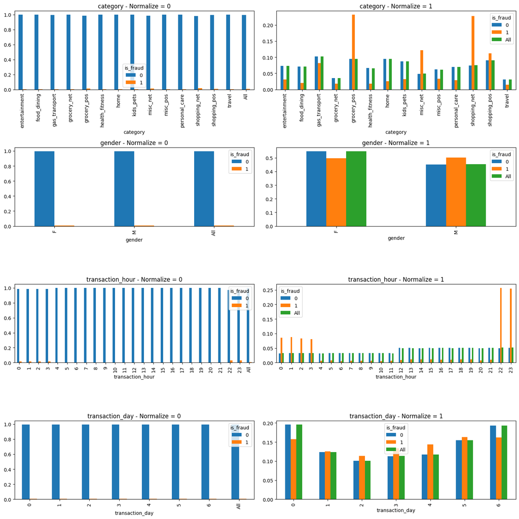

```python
mask = data_train.nunique() <= 30
data_cat = data_train.loc[:,mask].drop(columns="is_fraud")
fig, axes = plt.subplots(nrows=len(data_cat.columns), ncols=2, figsize=(15, 15))
for index, column in enumerate(data_cat.columns):
    crosstab_n1 = pd.crosstab(data_cat[column], data_train["is_fraud"], margins=True, normalize=1).round(3)
    crosstab_n0 = pd.crosstab(data_cat[column], data_train["is_fraud"], margins=True, normalize=0).round(3)
    crosstab_n0.plot(kind="bar", ax=axes[index, 0])
    axes[index, 0].set_title(f"{column} - Normalize = 0")
    crosstab_n1.plot(kind="bar", ax=axes[index, 1])
    axes[index, 1].set_title(f"{column} - Normalize = 1")
plt.show()
```

> Grafica 7. Diagrama de cajas variable *age* con respecto a la variable objetivo diferenciado por *gender*

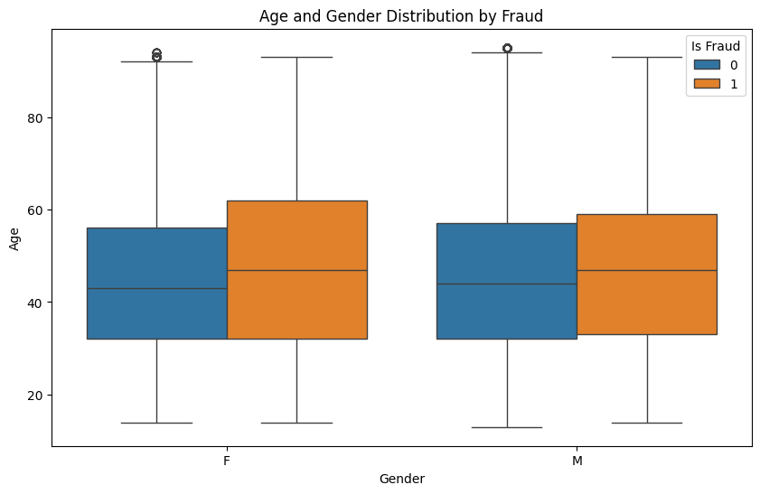

```python
plt.figure(figsize=(10, 6))
sns.boxplot(x="gender", y="age", hue="is_fraud", data=data_train)
plt.title("Age and Gender Distribution by Fraud")
plt.xlabel("Gender")
plt.ylabel("Age")
plt.legend(title="Is Fraud")
plt.show()
```

Obtenemos las siguientes conclusiones:

- "transaction_hour": Se percibe tendencia de operaciones fraudulentas en horarios nocturnos desde las 10 de la noche hasta las 3 de la manyana. La diferencia es bastante positiva, por lo que consideramos muy positivo la introducion de esta variable.
- "transacion_day": Balance un tanto desequilibrado, y no se aprecia un patron tan claro como en la variable anterior. No obstante, se observa cierta inclinacion a operaciones fraudulentas en los dias 2,3,4. Consideramos positiva su introducion.
- "age": Variable continua al contrario que las anteriores. Muestra una pequenya mayor tendencia a fraude a mayor edad del propietario de la tarjeta. Podria ser buena idea realizar una clasificacion de la variables para convertirla en categorica. Positiva inclusion.

> Anexo 4. Obtencion variables "transaction_amount_diff y "time_since_last_transaction" en *data_train*

Continuamos ampliando el contenido de nuestro conjunto de datos anyadiendo las siguientes variables.

- "transaction_amount_diff": Variable continua de comparacion del total de la transaccion ("amt") con respecto a la media de las transacciones realizadas en una misma tarjeta.
- "time_since_last_transaction": Varible continua que muestra el tiempo medido en segundos desde la ultima transaccion realizada en esa misma tarjeta. Se obtiene a traves de la variable "unix_time".

> Grafica 8. Distribucion variables *transaction_amount_diff* y *time_since_last_transaction* con respecto a la variable objetivo

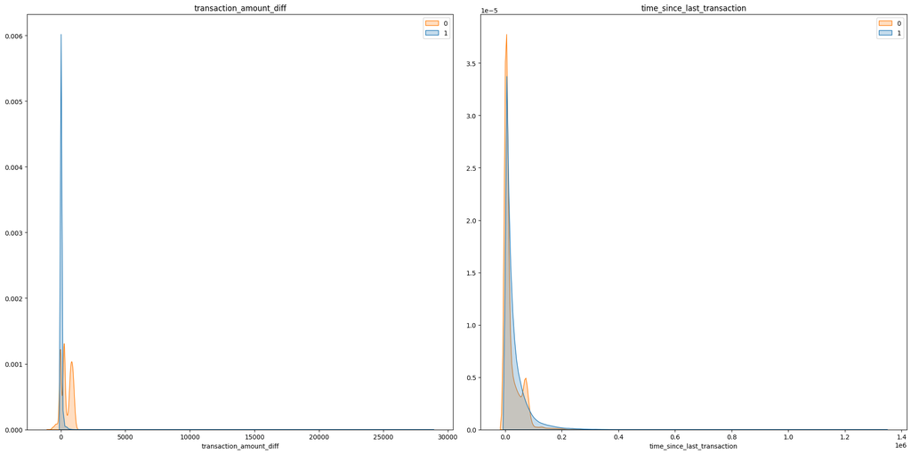

```python
fig, axes = plt.subplots(nrows=1, ncols=2, figsize=(20, 10))
axes = axes.ravel()
new_columns = ["transaction_amount_diff","time_since_last_transaction"]
for i, column in enumerate(new_columns):
    sns.kdeplot(data=data_train, x=column, hue=data_train["is_fraud"], fill=True, common_norm=False, ax=axes[i])
    axes[i].set_title(column)
    axes[i].legend(data_train["is_fraud"].value_counts().index)
```

A simple vista, notamos mejores resultados potenciales en la variable "transaction_amount_diff", dado que proporciona una mayor diferenciación entre los datos. Ambas variables son candidatas prometedoras para su inclusión en el modelo. Sin embargo, vamos a proceder con una clasificación de las variables continuas. Este proceso tiene como objetivo identificar patrones de comportamiento dentro de grupos de valores, lo que simplificará la tarea de predicción del modelo.

Para ello, nos servimos de la libreria OptBinning.

> Anexo 5. Procedimiento de categorizacion de variables continuas con *OptimalBinning*

Basandonos en el critero "Event Rate" y "IV", los cuales representan tasa de evento, asi como el valor de la informacion solo aplicamos intervalos a la variables "time_since_last_transaction", "transaction_amount_diff" y "amt". Realizamos una representacion grafica de ellos para observar con mas claridad su comportamiento y verifar nuestra hipotesis.

El resto de variables, las incluiremos en el modelo pero como variables continuas.

> Anexo 6. Diagrama de barras para las variables categoricas incluidas y obtenidas

En este anexo, se presenta un diagrama de barras que muestra la distribucion de las variable después de aplicar la categorización. Este diagrama proporciona una visualizacion clara de como se han agrupado los valores de esta variable en intervalos y cómo se distribuyen los datos dentro de cada intervalo, demostrando el buen comportamiento de la categorizacion para con la deteccion de transacciones fraudulentas.

> Anexo 7. Adicion de variables obtenidas y transformadas a *data train* y *data test*

Una vez incluida todas la variables que hemos considerado oportunas, realizamos la transformacion final, aplicando StandardScaler las variables localizadas en la lista "numerical_cols" y OneHotEncoder para "categorical_cols".

> Anexo 8. Importacion libreria de preprocesado, balanceo y division de datos

```python
numerical_cols = ["lat", "long", "merch_lat", "merch_long", "age", "transaction_hour","transaction_day"]
categorical_cols = ["gender", "category", "amt_binned", "time_since_last_transaction_binned", "transaction_amount_diff_binned"]
```

```python
numeric_transformer = StandardScaler()
categorical_transformer = OneHotEncoder(drop="first", handle_unknown="ignore")
preprocessor = ColumnTransformer(
    transformers=[("num", numeric_transformer, numerical_cols),
        ("cat", categorical_transformer, categorical_cols)
    ])
X_train_preprocessed = preprocessor.fit_transform(data_train[numerical_cols + categorical_cols])
X_test_preprocessed = preprocessor.transform(data_test[numerical_cols + categorical_cols ])
```

```python
X_test = X_test_preprocessed
y_train = data_train["is_fraud"]
y_test = data_test["is_fraud"]
```

El siguiente codigo implementa SMOTE, para abordar el desequilibrio de clases en el conjunto de entrenamiento.

Como senyalamos anteriormente, el conjunto de datos presentaba un notable desquilibrio de clases, el cual dificulta la capacidad de los modelos de para generalizar de manera efectiva, ya que pueden tener problemas para aprender patrones en las clases minoritarias. SMOTE aborda este problema generando muestras de la clase minoritaria al crear nuevos ejemplos a partir de los existentes.

```python
smote = SMOTE(random_state=36)
X_train, y_train = smote.fit_resample(X_train_preprocessed, y_train)
X_train, X_val, y_train, y_val = train_test_split(X_train, y_train, random_state = 42, test_size = 0.2)
```

## **5. Modelizacion**

Una vez se han realizado todas las operaciones, procedemos a buscar el modelo de machine learning que mas se adapte a nuestra necesidades. Hemos de tener un factor en cuenta a la hora de especificar el objetivo, y es que nos encontramos con un dataset muy descompensado en la distribucion de la valores de la variable objetivo. Por lo tanto, y teniendo en cuenta que nuestra tarea es la detectar transacciones fraudulentas, no nos serviria un alto *accuracy* sin un alto *recall*, ya que en este tipo de operaciones se intenta minimizar el numero de fraudes a costa de sospechar de las buenas transacciones.

Para este proyecto, vamos a intentar recopilar tres modelos, que ofrezcan predicciones para diversos escenarios. Un primer escenario donde se quieran predicciones con una alta precision, un segundo nivel donde haya un balance de sensibilidad y precision, y un ultimo con una mayor sensibilidad a movimientos fraudulentos. Eso si, buscamos que el *acuraccy* sea de al menos un 90% para cada uno de ellos. Para ello procedemos a entrenar varios modelos al mismo tiempo y procedemos a analizarlos.

> Anexo 9. Importacion e instancias de modelos y metricas

```python
for model in model_instances:
  NuestrasFunciones.models_train(model, X_train, y_train)
```

```
RandomForestClassifier
Training time: 937.79 seconds
------------------------
ExtraTreesClassifier
Training time: 578.22 seconds
------------------------
GaussianNB
Training time: 1.47 seconds
------------------------
DecisionTreeClassifier
Training time: 65.58 seconds
------------------------
GradientBoostingClassifier
Training time: 1387.31 seconds
------------------------
LogisticRegression
Training time: 36.34 seconds
------------------------
```

> Anexo 10. Matriz de confusion y curva ROC para *data_validation*

Veamos las metricas representadas en un tabla.

> Tabla 7. Metricas modelos para *data validation*

```python
NuestrasFunciones.model_comparison(model_instances, X_val, y_val)
```

|  | Model | Accuracy Val | ROC Score Val | F1 Score Val | Precision Score Val | Recall Score Val |
| --- | --- | --- | --- | --- | --- | --- |
| 0 | RandomForestClassifier | 0.999094 | 0.999094 | 0.999097 | 0.998832 | 0.999362 |
| 1 | ExtraTreesClassifier | 0.999267 | 0.999265 | 0.999269 | 0.998601 | 0.999938 |
| 2 | GaussianNB | 0.825580 | 0.825492 | 0.831800 | 0.805042 | 0.860396 |
| 3 | DecisionTreeClassifier | 0.997857 | 0.997856 | 0.997864 | 0.997245 | 0.998483 |
| 4 | GradientBoostingClassifier | 0.968561 | 0.968539 | 0.968908 | 0.960712 | 0.977244 |
| 5 | LogisticRegression | 0.923065 | 0.923053 | 0.923615 | 0.919333 | 0.927937 |

Los resultados de los *RandomForest* en validation son muy buenos, llegando casi a la perfeccion en todas las metricas. Todos los modelos estan bastante equilibrados en todos los niveles.

A continuacion, procemos a observar los resultados en test.

> Anexo 11. Matriz de confusion y curva ROC para *data test*

Nuevamente observamos las metricas para test en una tabla.

> Tabla 8. Metricas modelos para *data test*

```python
NuestrasFunciones.model_comparison(model_instances, X_test, y_test)
```

|  | Model | Accuracy Val | ROC Score Val | F1 Score Val | Precision Score Val | Recall Score Val |
| --- | --- | --- | --- | --- | --- | --- |
| 0 | RandomForestClassifier | 0.997618 | 0.855771 | 0.697855 | 0.683505 | 0.712821 |
| 1 | ExtraTreesClassifier | 0.997409 | 0.852647 | 0.677996 | 0.651483 | 0.706760 |
| 2 | GaussianNB | 0.791900 | 0.811027 | 0.029881 | 0.015214 | 0.830303 |
| 3 | DecisionTreeClassifier | 0.995402 | 0.846532 | 0.539058 | 0.439670 | 0.696503 |
| 4 | GradientBoostingClassifier | 0.959346 | 0.933619 | 0.147021 | 0.079988 | 0.907692 |
| 5 | LogisticRegression | 0.913300 | 0.910507 | 0.074777 | 0.038995 | 0.907692 |

Al igual que en validation, los dos *RandomForest* tienen un desempenyo excelente en *accuracy*, no obstante, pierden bastante rendimiento en *precision* y *F1Score*. Por otro lado, observamos un gran rendimiento tanto del *GradientBoostingClassifier* como del *LogisticRegression* en la tarea de detectar movimientos fraudulentos. Tenemos candidatos para un modelo de sensibilidad alta. Aunque no encontramos un modelo que ofreza una prediccion balanceada que nos convenza, vamos proceder a realizar un *GridSearch* para un *RandomForest* con *Recall* establecido como metrica a observar.

## **6. Tunning Parameters**

```python
params = {
    'n_estimators': [10, 20, 50, 100],
    'max_depth': [3, 5, 7, 10]
}
grid_search = GridSearchCV(rf_model, params, scoring='recall')
```

```python
NuestrasFunciones.models_train(grid_search, X_train, y_train)
```

```
GridSearchCV
Training time: 12055.52 seconds
------------------------
```

> Tabla 7. Metricas modelo GridSearch para *data test*

```python
model_instances.append(grid_search)
NuestrasFunciones.model_comparison(model_instances, X_test, y_test)
```

|  | Model | Accuracy Val | ROC Score Val | F1 Score Val | Precision Score Val | Recall Score Val |
| --- | --- | --- | --- | --- | --- | --- |
| 0 | RandomForestClassifier | 0.997618 | 0.855771 | 0.697855 | 0.683505 | 0.712821 |
| 1 | ExtraTreesClassifier | 0.997409 | 0.852647 | 0.677996 | 0.651483 | 0.706760 |
| 2 | GaussianNB | 0.791900 | 0.811027 | 0.029881 | 0.015214 | 0.830303 |
| 3 | DecisionTreeClassifier | 0.995402 | 0.846532 | 0.539058 | 0.439670 | 0.696503 |
| 4 | GradientBoostingClassifier | 0.959346 | 0.933619 | 0.147021 | 0.079988 | 0.907692 |
| 5 | LogisticRegression | 0.913300 | 0.910507 | 0.074777 | 0.038995 | 0.907692 |
| 6 | GridSearchCV | 0.963993 | 0.938970 | 0.163811 | 0.089970 | 0.913753 |

> Anexo 12. Matriz de confusion y curva ROC para modelo *GridSearch* con *data test*

## **7. Deep Learning**

Importamos las librerias necesarias.

> Anexo 13. Importacion librerias para modelo de red neuronal

Definimos el modelo. Modelo *Sequential* con dos capas ocultas con activacion *relu* en cada una, capa final con *sigmoid*. Para la compilacion utilizamos optimizador *Adam*, y como metric principal *accuracy*.

> Anexo 14. Definicion modelo Secuencial y entrenamiento

```python
loss, accuracy = model.evaluate(X_test, y_test)
print(f'Test Loss: {loss}, Test Accuracy: {accuracy}')
y_pred = model.predict(X_test)
y_pred_binary = (y_pred > 0.5).astype(int)
```

[output not shown]

```python
accuracy = accuracy_score(y_test, y_pred_binary)
roc_score = roc_auc_score(y_test, y_pred_binary)
f1 = f1_score(y_test, y_pred_binary)
precision = precision_score(y_test, y_pred_binary)
recall = recall_score(y_test, y_pred_binary)
print(f'Accuracy: {accuracy}')
print(f'ROC Score: {roc_score}')
print(f'F1 Score: {f1}')
print(f'Precision Score: {precision}')
print(f'Recall Score: {recall}')
```

```
Accuracy: 0.9855952378810154
ROC Score: 0.9272901537652051
F1 Score: 0.31761998124627056
Precision Score: 0.19434592113498853
Recall Score: 0.8685314685314686
```

> Anexo 15. Matriz de confusion modelo secuencial

Buen resultado del modelo. Desempenyo muy parecido a *GridSearch* anterior pero con un resultado en test menos satisfactorio. Por lo tanto, nos quedamos con la combinacion de modelos elegidas anteriormente.

## **8. Conlusiones**

En conclusion, tras un exhaustivo analisis y entrenamiento de diferentes modelos de machine learning, hemos identificado tres modelos que se adaptan a distintos escenarios segun las necesidades de nuestro proyecto:

> Modelo 1: Random Forest Classifier
- Característica Principal: Precision
- Buscamos una alta precisión en todas las predicciones, dando menor importancia a la detección de fraudes.

Cada modelo cumple con un proposito específico, y la eleccion entre ellos dependera de las prioridades y objetivos del cliente. Es importante destacar que, aunque los modelos de Random Forest han demostrado un desempeño excelente, la inclusion de un modelo de red neuronal tambien ha sido considerada, proporcionando resultados competitivos pero menos positivo que los modelos elegidos. Para facilitar la toma de decisiones, se ha desarrollado una tabla comparativa que resume las características y ventajas de cada modelo:

> Tabla 9. Caracteristicas principales modelos

[output not shown]

En resumen, la combinacion de estos modelos ofrece flexibilidad y versatilidad para abordar distintos escenarios, proporcionando a nuestro sistema la capacidad de adaptarse a las necesidades especificas del cliente.

> Anexo 16. Exportacion de modelos y prepocesadores

# **9. Anexos**

> Anexo 1. Codigo importacion de librerias

```python
!pip install optbinning
```

```python
from google.colab import drive
drive.mount("/content/drive")
```

```python
import joblib
import warnings
warnings.filterwarnings("ignore")

import pandas as pd
pd.set_option("display.max_columns", None)
from IPython.display import display
import numpy as np
import matplotlib.pyplot as plt
plt.rcParams["figure.figsize"] = (12,8)
import seaborn as sns

import NuestrasFunciones
```

```python
data_train = pd.read_csv("/content/drive/MyDrive/fraudTrain.csv", index_col=0)
data_test = pd.read_csv("/content/drive/MyDrive/fraudTest.csv", index_col=0)
```

> Anexo 2. Categorizacion variables cardinalidad inferior a diez

```python
NuestrasFunciones.categorizer(data_train)
NuestrasFunciones.categorizer(data_test)
```

> Anexo 3. Creacion de variables *transaction_hour*, *transaction_day* y *age* en *data_train*

```python
data_train["trans_date_trans_time"] = pd.to_datetime(data_train["trans_date_trans_time"])
data_train["dob"] = pd.to_datetime(data_train["dob"])
data_train["transaction_hour"] = data_train["trans_date_trans_time"].dt.hour
data_train["transaction_day"] = data_train["trans_date_trans_time"].dt.dayofweek
data_train["age"] = (data_train["trans_date_trans_time"] - data_train["dob"]).dt.days // 365
```

> Anexo 4. Obtencion variables "transaction_amount_diff y "time_since_last_transaction" en *data_train*

```python
data_train["mean_transaction_amount"] = data_train.groupby("cc_num")["amt"].transform("mean")
data_train["transaction_amount_diff"] = data_train["amt"] - data_train["mean_transaction_amount"]
```

```python
data_train["time_since_last_transaction"] = data_train.groupby("cc_num")["unix_time"].diff().fillna(0)
```

> Anexo 5. Procedimiento de categorizacion de variables continuas con *OptimalBinning*

```python
 from optbinning import OptimalBinning
```

```python
x = data_train["transaction_amount_diff"].values
y = data_train["is_fraud"]
```

```python
optb_meandiff = OptimalBinning(name="transaction_amount_diff", dtype="numerical", solver="cp", max_n_bins=4)
```

```python
optb_meandiff.fit(x, y)
```

```
OptimalBinning(max_n_bins=4, name='transaction_amount_diff')
```

```python
binning_table = optb_meandiff.binning_table
binning_table.build()
```

|  | Bin | Count | Count (%) | Non-event | Event | Event rate | WoE | IV | JS |
| --- | --- | --- | --- | --- | --- | --- | --- | --- | --- |
| 0 | (-inf, -70.61) | 64834 | 0.050000 | 64183 | 651 | 0.010041 | -0.555066 | 0.020507 | 0.002531 |
| 1 | [-70.61, -33.14) | 502425 | 0.387472 | 501326 | 1099 | 0.002187 | 0.976806 | 0.236835 | 0.028481 |
| 2 | [-33.14, 117.64) | 664582 | 0.512528 | 664265 | 317 | 0.000477 | 2.501484 | 1.183285 | 0.118433 |
| 3 | [117.64, inf) | 64834 | 0.050000 | 59395 | 5439 | 0.083891 | -2.755436 | 1.869695 | 0.179874 |
| 4 | Special | 0 | 0.000000 | 0 | 0 | 0.000000 | 0.0 | 0.000000 | 0.000000 |
| 5 | Missing | 0 | 0.000000 | 0 | 0 | 0.000000 | 0.0 | 0.000000 | 0.000000 |
| Totals |  | 1296675 | 1.000000 | 1289169 | 7506 | 0.005789 |  | 3.310322 | 0.329318 |

```python
x = data_train["time_since_last_transaction"].values
y = data_train["is_fraud"]
```

```python
optb_tslt = OptimalBinning(name="time_since_last_transaction", dtype="numerical", solver="cp", max_n_bins = 5)
```

```python
optb_tslt.fit(x, y)
```

```
OptimalBinning(max_n_bins=5, name='time_since_last_transaction')
```

```python
binning_table = optb_tslt.binning_table
binning_table.build()
```

|  | Bin | Count | Count (%) | Non-event | Event | Event rate | WoE | IV | JS |
| --- | --- | --- | --- | --- | --- | --- | --- | --- | --- |
| 0 | (-inf, 2733.50) | 167830 | 0.129431 | 164910 | 2920 | 0.017399 | -1.112234 | 0.290407 | 0.034538 |
| 1 | [2733.50, 5374.50) | 129134 | 0.099589 | 128135 | 999 | 0.007736 | -0.291966 | 0.009839 | 0.001226 |
| 2 | [5374.50, 8725.50) | 131775 | 0.101625 | 131201 | 574 | 0.004356 | 0.285806 | 0.007231 | 0.000901 |
| 3 | [8725.50, 46531.50) | 590965 | 0.455754 | 589305 | 1660 | 0.002809 | 0.726076 | 0.171328 | 0.020958 |
| 4 | [46531.50, inf) | 276971 | 0.213601 | 275618 | 1353 | 0.004885 | 0.170641 | 0.005723 | 0.000715 |
| 5 | Special | 0 | 0.000000 | 0 | 0 | 0.000000 | 0.0 | 0.000000 | 0.000000 |
| 6 | Missing | 0 | 0.000000 | 0 | 0 | 0.000000 | 0.0 | 0.000000 | 0.000000 |
| Totals |  | 1296675 | 1.000000 | 1289169 | 7506 | 0.005789 |  | 0.484528 | 0.058337 |

```python
x = data_train["city_pop"].values
y = data_train["is_fraud"]
```

```python
optb_city = OptimalBinning(name="city_pop", dtype="numerical", solver="cp")
```

```python
optb_city.fit(x, y)
```

```
OptimalBinning(name='city_pop')
```

```python
binning_table = optb_city.binning_table
binning_table.build()
```

|  | Bin | Count | Count (%) | Non-event | Event | Event rate | WoE | IV | JS |
| --- | --- | --- | --- | --- | --- | --- | --- | --- | --- |
| 0 | (-inf, 304.50) | 153459 | 0.118348 | 152472 | 987 | 0.006432 | -0.105984 | 0.001401 | 0.000175 |
| 1 | [304.50, 47230.00) | 895378 | 0.690518 | 890310 | 5068 | 0.005660 | 0.022573 | 0.000348 | 0.000043 |
| 2 | [47230.00, 131385.50) | 88972 | 0.068615 | 88596 | 376 | 0.004226 | 0.316202 | 0.005891 | 0.000733 |
| 3 | [131385.50, inf) | 158866 | 0.122518 | 157791 | 1075 | 0.006767 | -0.1571 | 0.003271 | 0.000408 |
| 4 | Special | 0 | 0.000000 | 0 | 0 | 0.000000 | 0.0 | 0.000000 | 0.000000 |
| 5 | Missing | 0 | 0.000000 | 0 | 0 | 0.000000 | 0.0 | 0.000000 | 0.000000 |
| Totals |  | 1296675 | 1.000000 | 1289169 | 7506 | 0.005789 |  | 0.010911 | 0.001360 |

```python
x = data_train["age"].values
y = data_train["is_fraud"]
```

```python
optb_age = OptimalBinning(name="age", dtype="numerical", solver="cp",  max_n_bins = 6)
```

```python
optb_age.fit(x, y)
```

```
OptimalBinning(max_n_bins=6, name='age')
```

```python
binning_table = optb_age.binning_table
binning_table.build()
```

|  | Bin | Count | Count (%) | Non-event | Event | Event rate | WoE | IV | JS |
| --- | --- | --- | --- | --- | --- | --- | --- | --- | --- |
| 0 | (-inf, 26.50) | 170221 | 0.131275 | 169156 | 1065 | 0.006257 | -0.078204 | 0.000835 | 0.000104 |
| 1 | [26.50, 33.50) | 199495 | 0.153851 | 198541 | 954 | 0.004782 | 0.192037 | 0.005167 | 0.000645 |
| 2 | [33.50, 36.50) | 97270 | 0.075015 | 96925 | 345 | 0.003547 | 0.492098 | 0.014380 | 0.001780 |
| 3 | [36.50, 48.50) | 348248 | 0.268570 | 346657 | 1591 | 0.004569 | 0.237923 | 0.013546 | 0.001689 |
| 4 | [48.50, 76.50) | 395712 | 0.305174 | 392960 | 2752 | 0.006955 | -0.18467 | 0.011417 | 0.001425 |
| 5 | [76.50, inf) | 85729 | 0.066114 | 84930 | 799 | 0.009320 | -0.479829 | 0.019466 | 0.002410 |
| 6 | Special | 0 | 0.000000 | 0 | 0 | 0.000000 | 0.0 | 0.000000 | 0.000000 |
| 7 | Missing | 0 | 0.000000 | 0 | 0 | 0.000000 | 0.0 | 0.000000 | 0.000000 |
| Totals |  | 1296675 | 1.000000 | 1289169 | 7506 | 0.005789 |  | 0.064811 | 0.008053 |

```python
x = data_train["amt"].values
y = data_train["is_fraud"]
```

```python
optb_amt = OptimalBinning(name="amt", dtype="numerical", solver="cp")
```

```python
optb_amt.fit(x,y)
```

```
OptimalBinning(name='amt')
```

```python
binning_table = optb_amt.binning_table
binning_table.build()
```

|  | Bin | Count | Count (%) | Non-event | Event | Event rate | WoE | IV | JS |
| --- | --- | --- | --- | --- | --- | --- | --- | --- | --- |
| 0 | (-inf, 24.27) | 457844 | 0.353091 | 456299 | 1545 | 0.003375 | 0.542074 | 0.080288 | 0.009915 |
| 1 | [24.27, 52.45) | 238579 | 0.183993 | 238480 | 99 | 0.000415 | 2.64087 | 0.453696 | 0.044443 |
| 2 | [52.45, 59.17) | 64933 | 0.050077 | 64931 | 2 | 0.000031 | 5.241883 | 0.262619 | 0.016716 |
| 3 | [59.17, 103.55) | 314847 | 0.242811 | 314837 | 10 | 0.000032 | 5.211175 | 1.265715 | 0.080962 |
| 4 | [103.55, 196.31) | 155637 | 0.120028 | 155492 | 145 | 0.000932 | 1.831565 | 0.185531 | 0.020412 |
| 5 | [196.31, inf) | 64835 | 0.050001 | 59130 | 5705 | 0.087993 | -2.807655 | 2.005204 | 0.191312 |
| 6 | Special | 0 | 0.000000 | 0 | 0 | 0.000000 | 0.0 | 0.000000 | 0.000000 |
| 7 | Missing | 0 | 0.000000 | 0 | 0 | 0.000000 | 0.0 | 0.000000 | 0.000000 |
| Totals |  | 1296675 | 1.000000 | 1289169 | 7506 | 0.005789 |  | 4.253053 | 0.363758 |

> Anexo 6. Diagrama de barras para las variables categoricas incluidas y obtenidas

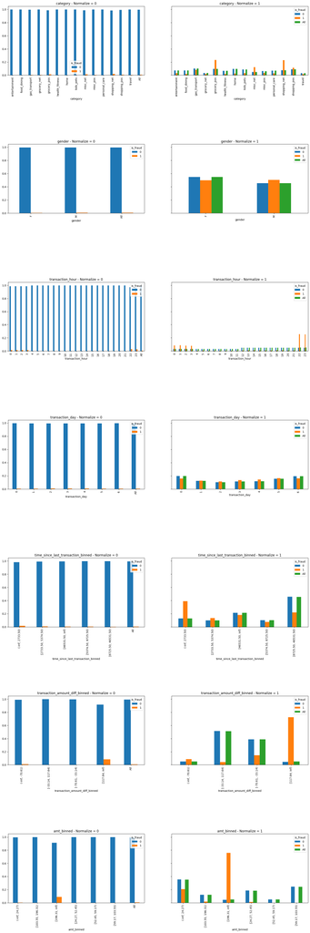

```python
mask = data_train.nunique() <= 30
data_cat = data_train.loc[:, mask].drop(columns="is_fraud")

fig, axes = plt.subplots(nrows=len(data_cat.columns), ncols=2, figsize=(20, 60), sharey="row", gridspec_kw={"hspace": 1})

for index, column in enumerate(data_cat.columns):
    crosstab_n0 = pd.crosstab(data_cat[column], data_train["is_fraud"], margins=True, normalize=0).round(3)
    crosstab_n1 = pd.crosstab(data_cat[column], data_train["is_fraud"], margins=True, normalize=1).round(3)

    crosstab_n0.plot(kind="bar", ax=axes[index, 0])
    axes[index, 0].set_title(f"{column} - Normalize = 0")

    crosstab_n1.plot(kind="bar", ax=axes[index, 1])
    axes[index, 1].set_title(f"{column} - Normalize = 1")

    axes[index, 0].tick_params(axis="x", rotation=90)
    axes[index, 1].tick_params(axis="x", rotation=90)

plt.show()
```

> Anexo 7. Adicion de variables obtenidas y transformadas a *data_train* y *data test*

```python
data_train["time_since_last_transaction_binned"] = optb_tslt.transform(data_train["time_since_last_transaction"], metric="bins")
data_train["transaction_amount_diff_binned"] = optb_meandiff.transform(data_train["transaction_amount_diff"], metric="bins")
data_train["amt_binned"] = optb_amt.transform(data_train["amt"], metric="bins")
```

```python
data_test["trans_date_trans_time"] = pd.to_datetime(data_test["trans_date_trans_time"])
data_test["dob"] = pd.to_datetime(data_test["dob"])
data_test["transaction_hour"] = data_test["trans_date_trans_time"].dt.hour
data_test["transaction_day"] = data_test["trans_date_trans_time"].dt.dayofweek
data_test["age"] = (data_test["trans_date_trans_time"] - data_test["dob"]).dt.days // 365
```

```python
data_test["mean_transaction_amount"] = data_test.groupby("cc_num")["amt"].transform("mean")
data_test["transaction_amount_diff"] = data_test["amt"] - data_test["mean_transaction_amount"]
data_test["time_since_last_transaction"] = data_test.groupby("cc_num")["unix_time"].diff().fillna(0)
```

```python
data_test["amt_binned"] = optb_amt.transform(data_test["amt"], metric="bins")
data_test["transaction_amount_diff_binned"] = optb_meandiff.transform(data_test["transaction_amount_diff"], metric="bins")
data_test["time_since_last_transaction_binned"] = optb_tslt.transform(data_test["time_since_last_transaction"], metric="bins")
```

> Anexo 8. Importacion libreria de preprocesado, balanceo y division de datos

```python
from sklearn.preprocessing import StandardScaler, OneHotEncoder
from sklearn.compose import ColumnTransformer
from imblearn.over_sampling import SMOTE
from sklearn.model_selection import train_test_split
```

> Anexo 9. Importacion e instancias de modelos y metricas

```python
from sklearn.model_selection import GridSearchCV
from sklearn.ensemble import RandomForestClassifier, GradientBoostingClassifier, ExtraTreesClassifier
from sklearn.linear_model import LogisticRegression
from sklearn.neighbors import KNeighborsClassifier
from sklearn.naive_bayes import GaussianNB
from sklearn.tree import DecisionTreeClassifier
from sklearn.metrics import accuracy_score, precision_score, recall_score, f1_score, roc_curve, auc, confusion_matrix, roc_auc_score
```

```python
rf_model = RandomForestClassifier()
et_model = ExtraTreesClassifier(random_state=42)
knn_model = KNeighborsClassifier()
nb_model = GaussianNB()
dt_model = DecisionTreeClassifier()
gb_model = GradientBoostingClassifier()
lg_model = LogisticRegression()
```

```python
model_names =[rf_model.__class__.__name__,
              et_model.__class__.__name__,
              nb_model.__class__.__name__,
              dt_model.__class__.__name__,
              gb_model.__class__.__name__,
              lg_model.__class__.__name__
              ]
model_instances = [rf_model,
                  et_model,
                  nb_model,
                  dt_model,
                  gb_model,
                  lg_model]
```

> Anexo 10. Matriz de confusion y curva ROC para *data_validation*

```
RandomForestClassifier
------------------------
```

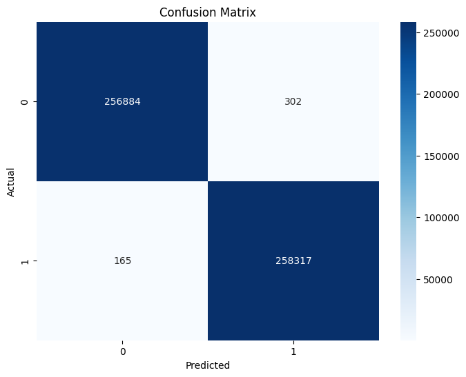

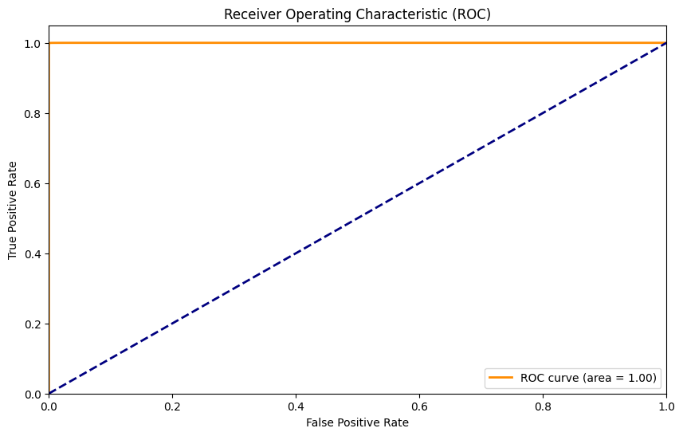

```
ExtraTreesClassifier
------------------------
```

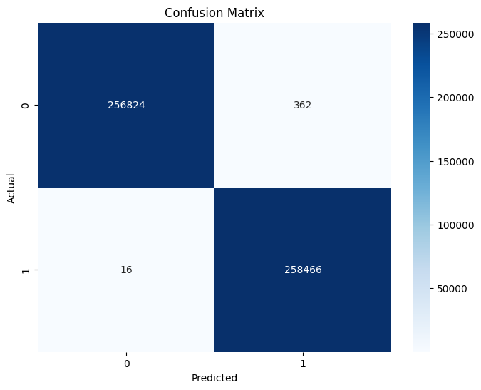

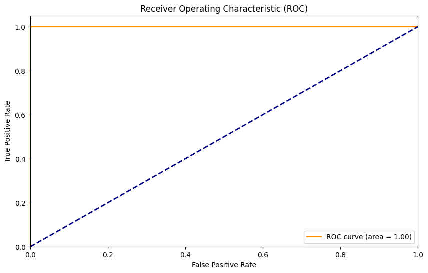

```
GaussianNB
------------------------
```

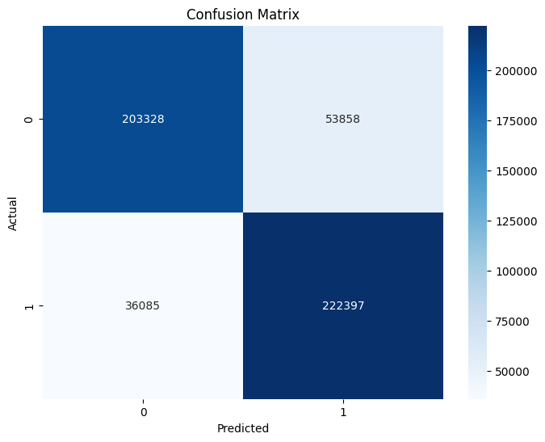

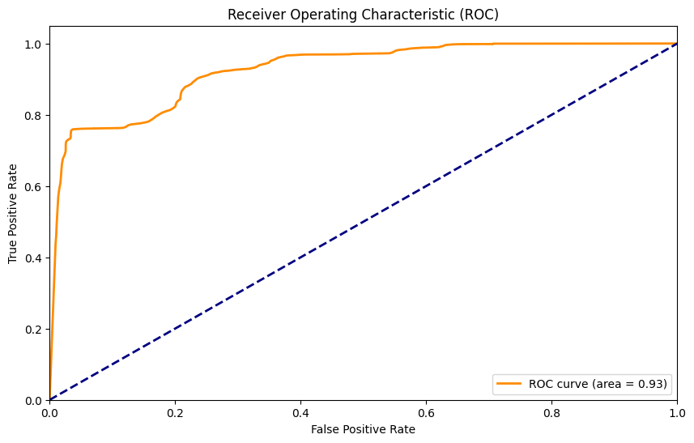

```
DecisionTreeClassifier
------------------------
```

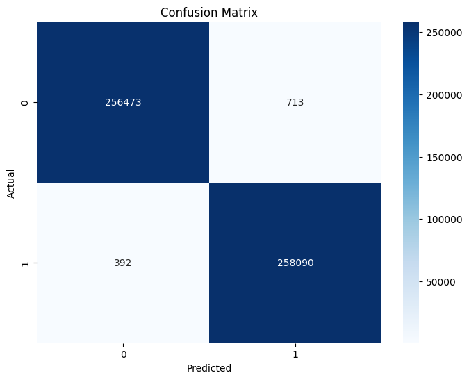

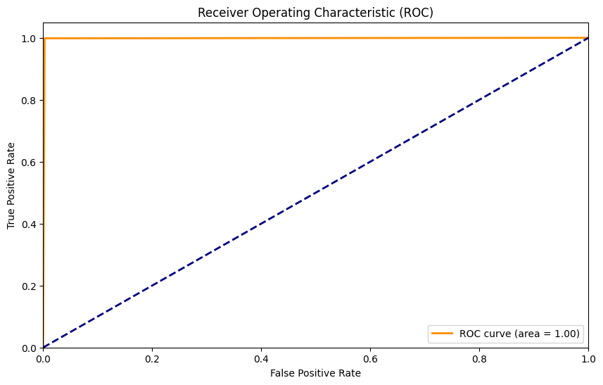

```
GradientBoostingClassifier
------------------------
```

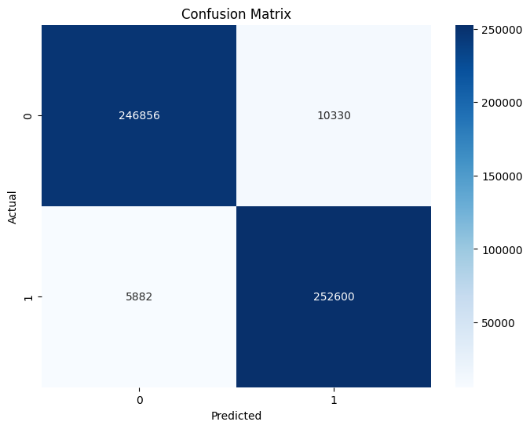

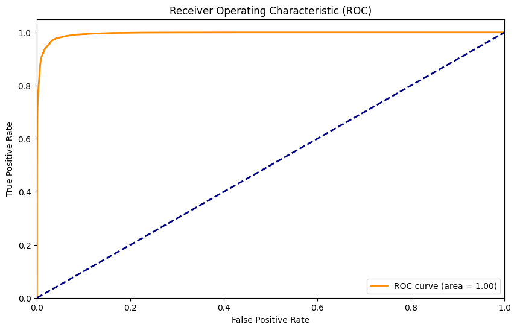

```
LogisticRegression
------------------------
```

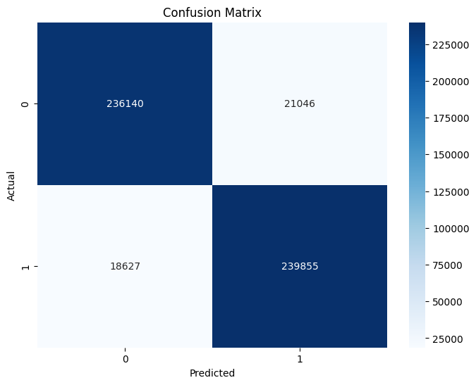

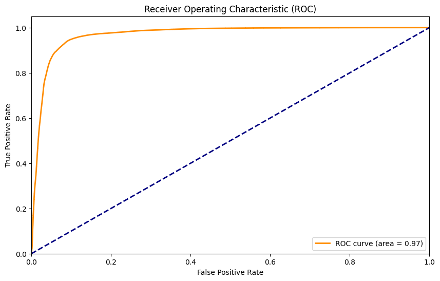

```python
for model in model_instances:
  NuestrasFunciones.metrics(model, X_val, y_val)
```

> Anexo 11. Matriz de confusion y curva ROC para *data test*